# Prova IA : Questão 1

## Thales Monteiro Soares

#### Multilabel classification emotion é uma base que contem informações de 593 músicas e suas emoções.

#### As emoções são:

```
* amazed-suprised;
* happy-pleased;
* relaxing-calm;
* quiet-still;
* sad-lonely;
* angry-aggresive;
```

#### Base utilizada: https://www.kaggle.com/srinivas365/multilabel-classification-emotions

# Análise de emoções em músicas

```python
import pandas as pd
import numpy as np
import matplotlib.pyplot as plt

from sklearn.preprocessing import LabelEncoder, OneHotEncoder


%matplotlib notebook
```

### Realizando leitura do dataframe emotions.arff

```python
from scipy.io import arff

data = arff.loadarff('emotions.arff')
df = pd.DataFrame(data[0])
```

### As classes estão como binárias, foi necessário converter para inteiro.

```python
df.iloc[:, 72:] = df.iloc[:, 72:].astype('int')
```

### Visualização das colunas do dataframe

##### Note que a base é multilabel, ou seja, cada música pode apresentar mais de uma classificação.

```python
df.head()
```

|  | Mean_Acc1298_Mean_Mem40_Centroid | Mean_Acc1298_Mean_Mem40_Rolloff | Mean_Acc1298_Mean_Mem40_Flux | Mean_Acc1298_Mean_Mem40_MFCC_0 | Mean_Acc1298_Mean_Mem40_MFCC_1 | Mean_Acc1298_Mean_Mem40_MFCC_2 | Mean_Acc1298_Mean_Mem40_MFCC_3 | Mean_Acc1298_Mean_Mem40_MFCC_4 | Mean_Acc1298_Mean_Mem40_MFCC_5 | Mean_Acc1298_Mean_Mem40_MFCC_6 | ... | BH_HighLowRatio | BHSUM1 | BHSUM2 | BHSUM3 | amazed-suprised | happy-pleased | relaxing-calm | quiet-still | sad-lonely | angry-aggresive |
| --- | --- | --- | --- | --- | --- | --- | --- | --- | --- | --- | --- | --- | --- | --- | --- | --- | --- | --- | --- | --- | --- |
| 0 | 0.034741 | 0.089665 | 0.091225 | -73.302422 | 6.215179 | 0.615074 | 2.037160 | 0.804065 | 1.301409 | 0.558576 | ... | 2.0 | 0.245457 | 0.105065 | 0.405399 | 0 | 1 | 1 | 0 | 0 | 0 |
| 1 | 0.081374 | 0.272747 | 0.085733 | -62.584437 | 3.183163 | -0.218145 | 0.163038 | 0.620251 | 0.458514 | 0.041426 | ... | 2.0 | 0.343547 | 0.276366 | 0.710924 | 1 | 0 | 0 | 0 | 0 | 1 |
| 2 | 0.110545 | 0.273567 | 0.084410 | -65.235325 | 2.794964 | 0.639047 | 1.281297 | 0.757896 | 0.489412 | 0.627636 | ... | 3.0 | 0.188693 | 0.045941 | 0.457372 | 0 | 1 | 0 | 0 | 0 | 1 |
| 3 | 0.042481 | 0.199281 | 0.093447 | -80.305152 | 5.824409 | 0.648848 | 1.754870 | 1.495532 | 0.739909 | 0.809644 | ... | 2.0 | 0.102839 | 0.241934 | 0.351009 | 0 | 0 | 1 | 0 | 0 | 0 |
| 4 | 0.074550 | 0.140880 | 0.079789 | -93.697749 | 5.543229 | 1.064262 | 0.899152 | 0.890336 | 0.702328 | 0.490685 | ... | 2.0 | 0.195196 | 0.310801 | 0.683817 | 0 | 0 | 0 | 1 | 0 | 0 |

5 rows × 78 columns

# Pré processamento dos dados

### Verificando se há instâncias com atributos duplicados

#### Foi verificado que não há instâncias duplicadas

```python
print('Valores duplicados:', df.duplicated().value_counts())
```

```
Valores duplicados: False    593
dtype: int64
```

### Verificando quantidade de valores ausentes

#### Foi verificado zero células com valores nulos

```python
print('Valores Ausentes:', df.isnull().sum().value_counts())
```

```
Valores Ausentes: 0    78
dtype: int64
```

### Realizando Matriz de correlação

#### Verificamos que algumas colunas apresentam alto indice de correlação

```python
corr = df.corr()
corr.style.background_gradient("coolwarm")
```

|  | Mean_Acc1298_Mean_Mem40_Centroid | Mean_Acc1298_Mean_Mem40_Rolloff | Mean_Acc1298_Mean_Mem40_Flux | Mean_Acc1298_Mean_Mem40_MFCC_0 | Mean_Acc1298_Mean_Mem40_MFCC_1 | Mean_Acc1298_Mean_Mem40_MFCC_2 | Mean_Acc1298_Mean_Mem40_MFCC_3 | Mean_Acc1298_Mean_Mem40_MFCC_4 | Mean_Acc1298_Mean_Mem40_MFCC_5 | Mean_Acc1298_Mean_Mem40_MFCC_6 | Mean_Acc1298_Mean_Mem40_MFCC_7 | Mean_Acc1298_Mean_Mem40_MFCC_8 | Mean_Acc1298_Mean_Mem40_MFCC_9 | Mean_Acc1298_Mean_Mem40_MFCC_10 | Mean_Acc1298_Mean_Mem40_MFCC_11 | Mean_Acc1298_Mean_Mem40_MFCC_12 | Mean_Acc1298_Std_Mem40_Centroid | Mean_Acc1298_Std_Mem40_Rolloff | Mean_Acc1298_Std_Mem40_Flux | Mean_Acc1298_Std_Mem40_MFCC_0 | Mean_Acc1298_Std_Mem40_MFCC_1 | Mean_Acc1298_Std_Mem40_MFCC_2 | Mean_Acc1298_Std_Mem40_MFCC_3 | Mean_Acc1298_Std_Mem40_MFCC_4 | Mean_Acc1298_Std_Mem40_MFCC_5 | Mean_Acc1298_Std_Mem40_MFCC_6 | Mean_Acc1298_Std_Mem40_MFCC_7 | Mean_Acc1298_Std_Mem40_MFCC_8 | Mean_Acc1298_Std_Mem40_MFCC_9 | … |
| --- | --- | --- | --- | --- | --- | --- | --- | --- | --- | --- | --- | --- | --- | --- | --- | --- | --- | --- | --- | --- | --- | --- | --- | --- | --- | --- | --- | --- | --- | --- |
| Mean_Acc1298_Mean_Mem40_Centroid | 1 | 0.632846 | 0.164513 | 0.369808 | -0.642412 | -0.211317 | -0.293023 | -0.203168 | -0.274803 | -0.0709384 | -0.0503027 | 0.106875 | -0.0271201 | 0.0602796 | 0.0752492 | -0.00262256 | 0.72639 | 0.233859 | -0.0175166 | 0.0064103 | -0.00588026 | 0.120326 | 0.156554 | 0.145269 | 0.15651 | 0.158141 | 0.135385 | 0.137241 | 0.130419 | … |
| Mean_Acc1298_Mean_Mem40_Rolloff | 0.632846 | 1 | 0.578299 | 0.291996 | -0.706719 | 0.0681217 | -0.322313 | 0.064595 | -0.205271 | 0.114298 | 0.039633 | 0.258674 | 0.0908773 | 0.140807 | 0.123487 | 0.121092 | 0.752729 | 0.809104 | 0.476947 | 0.378774 | 0.312443 | 0.349946 | 0.280552 | 0.241402 | 0.190011 | 0.189095 | 0.120259 | 0.0314013 | 0.0190372 | … |
| Mean_Acc1298_Mean_Mem40_Flux | 0.164513 | 0.578299 | 1 | 0.0573847 | -0.362375 | 0.15048 | -0.0975669 | 0.181392 | -0.0386366 | 0.205862 | 0.158235 | 0.204782 | 0.0872016 | 0.115501 | 0.124817 | 0.152076 | 0.569908 | 0.731653 | 0.918164 | 0.767852 | 0.719133 | 0.644317 | 0.552559 | 0.530501 | 0.488974 | 0.431579 | 0.36435 | 0.251058 | 0.19716 | … |
| Mean_Acc1298_Mean_Mem40_MFCC_0 | 0.369808 | 0.291996 | 0.0573847 | 1 | -0.552446 | -0.200284 | -0.14709 | -0.213496 | -0.187157 | -0.0986498 | 0.0288814 | 0.00316221 | -0.00886001 | 0.0533524 | -0.0695789 | -0.0902355 | 0.241019 | 0.160082 | -0.0420729 | -0.20229 | -0.0959399 | 0.00408013 | 0.124089 | 0.0838472 | 0.0437887 | 0.0260838 | -0.014454 | -0.0955949 | -0.122308 | … |
| Mean_Acc1298_Mean_Mem40_MFCC_1 | -0.642412 | -0.706719 | -0.362375 | -0.552446 | 1 | -0.0883562 | 0.17327 | -0.0360941 | 0.175458 | -0.153939 | -0.170889 | -0.26027 | -0.142591 | -0.209899 | -0.217846 | -0.130238 | -0.703551 | -0.60107 | -0.188562 | -0.22583 | -0.14025 | -0.323369 | -0.334954 | -0.279807 | -0.249398 | -0.219776 | -0.159643 | -0.108809 | -0.0379365 | … |
| Mean_Acc1298_Mean_Mem40_MFCC_2 | -0.211317 | 0.0681217 | 0.15048 | -0.200284 | -0.0883562 | 1 | -0.0260634 | 0.463654 | 0.0757473 | 0.214768 | 0.0855288 | 0.0574053 | 0.081408 | 0.0182149 | 0.0255083 | 0.107912 | 0.147358 | 0.29878 | 0.210685 | 0.296905 | 0.323921 | 0.265637 | 0.161439 | 0.117834 | 0.0568522 | 0.0570296 | 0.0234033 | -0.0649104 | -0.0659353 | … |
| Mean_Acc1298_Mean_Mem40_MFCC_3 | -0.293023 | -0.322313 | -0.0975669 | -0.14709 | 0.17327 | -0.0260634 | 1 | -0.111752 | 0.210669 | 0.0587267 | -0.0413715 | -0.115167 | -0.066436 | -0.0238676 | 0.0617076 | -0.0181372 | -0.282596 | -0.248059 | -0.0694914 | 0.0195002 | -0.00596102 | 0.00927819 | 0.137693 | 0.115355 | 0.135411 | 0.147832 | 0.154083 | 0.115554 | 0.109459 | … |
| Mean_Acc1298_Mean_Mem40_MFCC_4 | -0.203168 | 0.064595 | 0.181392 | -0.213496 | -0.0360941 | 0.463654 | -0.111752 | 1 | 0.114219 | 0.352446 | 0.163796 | 0.0598775 | 0.165259 | 0.103881 | 0.047189 | 0.128305 | 0.157204 | 0.269775 | 0.233094 | 0.277966 | 0.285835 | 0.285165 | 0.121017 | 0.0986488 | 0.0675944 | 0.0342178 | -0.0597757 | -0.108577 | -0.12106 | … |
| Mean_Acc1298_Mean_Mem40_MFCC_5 | -0.274803 | -0.205271 | -0.0386366 | -0.187157 | 0.175458 | 0.0757473 | 0.210669 | 0.114219 | 1 | 0.0618136 | 0.152361 | 0.0163136 | 0.14324 | 0.134646 | 0.0197096 | 0.0269967 | -0.161001 | -0.119957 | 0.0233591 | 0.0759088 | 0.0565313 | -0.0205749 | -0.121601 | -0.0748046 | -0.149902 | -0.104099 | -0.168413 | -0.112417 | -0.0889238 | … |
| Mean_Acc1298_Mean_Mem40_MFCC_6 | -0.0709384 | 0.114298 | 0.205862 | -0.0986498 | -0.153939 | 0.214768 | 0.0587267 | 0.352446 | 0.0618136 | 1 | 0.179357 | 0.215339 | 0.126791 | 0.169549 | 0.0708849 | 0.144492 | 0.201413 | 0.267825 | 0.193645 | 0.260895 | 0.234272 | 0.302416 | 0.288077 | 0.218175 | 0.172913 | 0.146845 | 0.0758213 | -0.0526334 | -0.0609743 | … |
| Mean_Acc1298_Mean_Mem40_MFCC_7 | -0.0503027 | 0.039633 | 0.158235 | 0.0288814 | -0.170889 | 0.0855288 | -0.0413715 | 0.163796 | 0.152361 | 0.179357 | 1 | 0.332905 | 0.243468 | 0.03239 | 0.00763682 | 0.0596914 | 0.0932322 | 0.130621 | 0.165242 | 0.0989136 | 0.109189 | 0.0786827 | 0.0180711 | -0.00823807 | 0.0091432 | -0.00590279 | -0.12067 | -0.0292919 | -0.157621 | … |
| Mean_Acc1298_Mean_Mem40_MFCC_8 | 0.106875 | 0.258674 | 0.204782 | 0.00316221 | -0.26027 | 0.0574053 | -0.115167 | 0.0598775 | 0.0163136 | 0.215339 | 0.332905 | 1 | 0.316859 | 0.10124 | -0.044799 | 0.147953 | 0.277005 | 0.33181 | 0.185343 | 0.189615 | 0.145081 | 0.188453 | 0.160312 | 0.121002 | 0.113118 | 0.0342476 | 0.000674607 | -0.0308571 | -0.131476 | … |
| Mean_Acc1298_Mean_Mem40_MFCC_9 | -0.0271201 | 0.0908773 | 0.0872016 | -0.00886001 | -0.142591 | 0.081408 | -0.066436 | 0.165259 | 0.14324 | 0.126791 | 0.243468 | 0.316859 | 1 | 0.21117 | 0.114182 | 0.189532 | 0.0752511 | 0.142924 | 0.0945348 | 0.105717 | 0.0572766 | 0.0425336 | 0.0422325 | 0.0134377 | 0.0129872 | 0.0329527 | -0.0998429 | -0.0731322 | -0.141727 | … |
| Mean_Acc1298_Mean_Mem40_MFCC_10 | 0.0602796 | 0.140807 | 0.115501 | 0.0533524 | -0.209899 | 0.0182149 | -0.0238676 | 0.103881 | 0.134646 | 0.169549 | 0.03239 | 0.10124 | 0.21117 | 1 | 0.221059 | 0.216939 | 0.171695 | 0.169531 | 0.065739 | 0.095846 | 0.0866497 | 0.112148 | 0.114344 | 0.122173 | 0.0680222 | 0.0847044 | -0.0168169 | -0.0301026 | 0.000495493 | … |
| Mean_Acc1298_Mean_Mem40_MFCC_11 | 0.0752492 | 0.123487 | 0.124817 | -0.0695789 | -0.217846 | 0.0255083 | 0.0617076 | 0.047189 | 0.0197096 | 0.0708849 | 0.00763682 | -0.044799 | 0.114182 | 0.221059 | 1 | 0.250408 | 0.144779 | 0.137116 | 0.0827995 | 0.155585 | 0.0385611 | 0.145654 | 0.0910452 | 0.109371 | 0.117903 | 0.0522173 | 0.054267 | 0.0510445 | 0.000992343 | … |
| Mean_Acc1298_Mean_Mem40_MFCC_12 | -0.00262256 | 0.121092 | 0.152076 | -0.0902355 | -0.130238 | 0.107912 | -0.0181372 | 0.128305 | 0.0269967 | 0.144492 | 0.0596914 | 0.147953 | 0.189532 | 0.216939 | 0.250408 | 1 | 0.168867 | 0.201821 | 0.158562 | 0.191422 | 0.194376 | 0.194802 | 0.194571 | 0.135185 | 0.186565 | 0.1554 | 0.0692832 | 0.0110977 | -0.0309365 | … |
| Mean_Acc1298_Std_Mem40_Centroid | 0.72639 | 0.752729 | 0.569908 | 0.241019 | -0.703551 | 0.147358 | -0.282596 | 0.157204 | -0.161001 | 0.201413 | 0.0932322 | 0.277005 | 0.0752511 | 0.171695 | 0.144779 | 0.168867 | 1 | 0.689094 | 0.412135 | 0.498061 | 0.481614 | 0.556295 | 0.515622 | 0.478724 | 0.431545 | 0.400595 | 0.305239 | 0.225235 | 0.156943 | … |
| Mean_Acc1298_Std_Mem40_Rolloff | 0.233859 | 0.809104 | 0.731653 | 0.160082 | -0.60107 | 0.29878 | -0.248059 | 0.269775 | -0.119957 | 0.267825 | 0.130621 | 0.33181 | 0.142924 | 0.169531 | 0.137116 | 0.201821 | 0.689094 | 1 | 0.668171 | 0.642537 | 0.578268 | 0.58868 | 0.500148 | 0.446268 | 0.373487 | 0.334215 | 0.238642 | 0.115776 | 0.0654876 | … |
| Mean_Acc1298_Std_Mem40_Flux | -0.0175166 | 0.476947 | 0.918164 | -0.0420729 | -0.188562 | 0.210685 | -0.0694914 | 0.233094 | 0.0233591 | 0.193645 | 0.165242 | 0.185343 | 0.0945348 | 0.065739 | 0.0827995 | 0.158562 | 0.412135 | 0.668171 | 1 | 0.770953 | 0.726113 | 0.58205 | 0.435247 | 0.398468 | 0.352504 | 0.300359 | 0.238427 | 0.142025 | 0.068774 | … |
| Mean_Acc1298_Std_Mem40_MFCC_0 | 0.0064103 | 0.378774 | 0.767852 | -0.20229 | -0.22583 | 0.296905 | 0.0195002 | 0.277966 | 0.0759088 | 0.260895 | 0.0989136 | 0.189615 | 0.105717 | 0.095846 | 0.155585 | 0.191422 | 0.498061 | 0.642537 | 0.770953 | 1 | 0.797146 | 0.773435 | 0.616083 | 0.594158 | 0.521547 | 0.504432 | 0.408641 | 0.309131 | 0.236196 | … |
| Mean_Acc1298_Std_Mem40_MFCC_1 | -0.00588026 | 0.312443 | 0.719133 | -0.0959399 | -0.14025 | 0.323921 | -0.00596102 | 0.285835 | 0.0565313 | 0.234272 | 0.109189 | 0.145081 | 0.0572766 | 0.0866497 | 0.0385611 | 0.194376 | 0.481614 | 0.578268 | 0.726113 | 0.797146 | 1 | 0.755237 | 0.619248 | 0.591145 | 0.52957 | 0.493019 | 0.396647 | 0.258011 | 0.231633 | … |
| Mean_Acc1298_Std_Mem40_MFCC_2 | 0.120326 | 0.349946 | 0.644317 | 0.00408013 | -0.323369 | 0.265637 | 0.00927819 | 0.285165 | -0.0205749 | 0.302416 | 0.0786827 | 0.188453 | 0.0425336 | 0.112148 | 0.145654 | 0.194802 | 0.556295 | 0.58868 | 0.58205 | 0.773435 | 0.755237 | 1 | 0.761924 | 0.730326 | 0.670422 | 0.604947 | 0.48643 | 0.347234 | 0.280067 | … |
| Mean_Acc1298_Std_Mem40_MFCC_3 | 0.156554 | 0.280552 | 0.552559 | 0.124089 | -0.334954 | 0.161439 | 0.137693 | 0.121017 | -0.121601 | 0.288077 | 0.0180711 | 0.160312 | 0.0422325 | 0.114344 | 0.0910452 | 0.194571 | 0.515622 | 0.500148 | 0.435247 | 0.616083 | 0.619248 | 0.761924 | 1 | 0.884336 | 0.831501 | 0.781751 | 0.678669 | 0.498446 | 0.427477 | … |
| Mean_Acc1298_Std_Mem40_MFCC_4 | 0.145269 | 0.241402 | 0.530501 | 0.0838472 | -0.279807 | 0.117834 | 0.115355 | 0.0986488 | -0.0748046 | 0.218175 | -0.00823807 | 0.121002 | 0.0134377 | 0.122173 | 0.109371 | 0.135185 | 0.478724 | 0.446268 | 0.398468 | 0.594158 | 0.591145 | 0.730326 | 0.884336 | 1 | 0.839038 | 0.818145 | 0.754478 | 0.574396 | 0.553254 | … |
| Mean_Acc1298_Std_Mem40_MFCC_5 | 0.15651 | 0.190011 | 0.488974 | 0.0437887 | -0.249398 | 0.0568522 | 0.135411 | 0.0675944 | -0.149902 | 0.172913 | 0.0091432 | 0.113118 | 0.0129872 | 0.0680222 | 0.117903 | 0.186565 | 0.431545 | 0.373487 | 0.352504 | 0.521547 | 0.52957 | 0.670422 | 0.831501 | 0.839038 | 1 | 0.84925 | 0.778855 | 0.646917 | 0.585354 | … |
| Mean_Acc1298_Std_Mem40_MFCC_6 | 0.158141 | 0.189095 | 0.431579 | 0.0260838 | -0.219776 | 0.0570296 | 0.147832 | 0.0342178 | -0.104099 | 0.146845 | -0.00590279 | 0.0342476 | 0.0329527 | 0.0847044 | 0.0522173 | 0.1554 | 0.400595 | 0.334215 | 0.300359 | 0.504432 | 0.493019 | 0.604947 | 0.781751 | 0.818145 | 0.84925 | 1 | 0.810537 | 0.693358 | 0.66033 | … |
| Mean_Acc1298_Std_Mem40_MFCC_7 | 0.135385 | 0.120259 | 0.36435 | -0.014454 | -0.159643 | 0.0234033 | 0.154083 | -0.0597757 | -0.168413 | 0.0758213 | -0.12067 | 0.000674607 | -0.0998429 | -0.0168169 | 0.054267 | 0.0692832 | 0.305239 | 0.238642 | 0.238427 | 0.408641 | 0.396647 | 0.48643 | 0.678669 | 0.754478 | 0.778855 | 0.810537 | 1 | 0.79238 | 0.749988 | … |
| Mean_Acc1298_Std_Mem40_MFCC_8 | 0.137241 | 0.0314013 | 0.251058 | -0.0955949 | -0.108809 | -0.0649104 | 0.115554 | -0.108577 | -0.112417 | -0.0526334 | -0.0292919 | -0.0308571 | -0.0731322 | -0.0301026 | 0.0510445 | 0.0110977 | 0.225235 | 0.115776 | 0.142025 | 0.309131 | 0.258011 | 0.347234 | 0.498446 | 0.574396 | 0.646917 | 0.693358 | 0.79238 | 1 | 0.768454 | … |
| Mean_Acc1298_Std_Mem40_MFCC_9 | 0.130419 | 0.0190372 | 0.19716 | -0.122308 | -0.0379365 | -0.0659353 | 0.109459 | -0.12106 | -0.0889238 | -0.0609743 | -0.157621 | -0.131476 | -0.141727 | 0.000495493 | 0.000992343 | -0.0309365 | 0.156943 | 0.0654876 | 0.068774 | 0.236196 | 0.231633 | 0.280067 | 0.427477 | 0.553254 | 0.585354 | 0.66033 | 0.749988 | 0.768454 | 1 | … |
| Mean_Acc1298_Std_Mem40_MFCC_10 | 0.121749 | -0.037809 | 0.104767 | -0.176925 | 0.00195203 | -0.08418 | 0.0999993 | -0.201579 | -0.0589528 | -0.115174 | -0.108845 | -0.106517 | -0.161569 | 0.00479612 | -0.0429085 | -0.0592204 | 0.0882638 | -0.0252182 | -0.00912855 | 0.166685 | 0.151113 | 0.196846 | 0.284631 | 0.393852 | 0.473478 | 0.562472 | 0.641319 | 0.703883 | 0.81919 | … |
| Mean_Acc1298_Std_Mem40_MFCC_11 | 0.110312 | -0.0704762 | 0.0711349 | -0.135366 | -0.0168105 | -0.0772934 | 0.118405 | -0.150295 | -0.0537611 | -0.108543 | -0.145424 | -0.153717 | -0.172024 | -0.00280647 | 0.00988635 | -0.102492 | 0.0694209 | -0.0441153 | -0.0250317 | 0.166024 | 0.135461 | 0.215006 | 0.275811 | 0.372551 | 0.426205 | 0.526309 | 0.580514 | 0.677345 | 0.748537 | … |
| Mean_Acc1298_Std_Mem40_MFCC_12 | 0.0738147 | -0.0622619 | 0.0547616 | -0.151404 | 0.0189524 | -0.0611684 | 0.110966 | -0.126144 | -0.0468816 | -0.131161 | -0.209946 | -0.194684 | -0.172666 | -0.0525781 | -0.00466939 | -0.152064 | 0.0137596 | -0.0717105 | -0.0164215 | 0.13926 | 0.0847622 | 0.15053 | 0.171505 | 0.263283 | 0.30779 | 0.381623 | 0.462389 | 0.577348 | 0.663227 | … |
| Std_Acc1298_Mean_Mem40_Centroid | 0.507491 | 0.408624 | 0.241115 | 0.0237249 | -0.368817 | 0.0776249 | -0.0698425 | 0.0377067 | -0.14005 | 0.0900588 | -0.0280207 | 0.0411194 | 0.00991149 | 0.0156656 | 0.0855485 | 0.0574255 | 0.480687 | 0.276621 | 0.141973 | 0.256384 | 0.215284 | 0.251358 | 0.277766 | 0.269715 | 0.250608 | 0.26917 | 0.230411 | 0.145698 | 0.193314 | … |
| Std_Acc1298_Mean_Mem40_Rolloff | 0.0494246 | 0.446865 | 0.325986 | -0.0969594 | -0.273153 | 0.275485 | -0.0425339 | 0.182095 | -0.0782031 | 0.155012 | -0.00317699 | 0.133095 | 0.0375328 | 0.0860027 | 0.127641 | 0.106153 | 0.283892 | 0.544808 | 0.338037 | 0.395366 | 0.291423 | 0.305825 | 0.245306 | 0.199353 | 0.132326 | 0.153505 | 0.116071 | 0.0354109 | 0.00680981 | … |
| Std_Acc1298_Mean_Mem40_Flux | -0.0585523 | 0.152393 | 0.412041 | -0.0952912 | 0.0887412 | 0.0998877 | -0.0242327 | 0.0955906 | 0.0396325 | -0.0098087 | 0.0493198 | -0.0287076 | 0.027196 | -0.0140769 | 0.0240559 | 0.0279481 | 0.040597 | 0.157085 | 0.507938 | 0.292272 | 0.308625 | 0.148861 | 0.0634379 | 0.0973491 | 0.0731628 | 0.0562385 | 0.0517529 | -0.00666293 | -0.00469147 | … |
| Std_Acc1298_Mean_Mem40_MFCC_0 | -0.267902 | -0.321233 | -0.173676 | -0.680277 | 0.499895 | -0.0121945 | 0.165274 | -0.00702798 | 0.110993 | -0.0533381 | -0.102526 | -0.119189 | -0.0407149 | -0.0968074 | 0.00181409 | -0.0410393 | -0.313477 | -0.302716 | -0.0914084 | 0.0558104 | -0.0334213 | -0.151749 | -0.176691 | -0.139011 | -0.108292 | -0.0757465 | -0.0107456 | 0.057143 | 0.0875954 | … |
| Std_Acc1298_Mean_Mem40_MFCC_1 | -0.256984 | -0.340561 | -0.210467 | -0.543292 | 0.533147 | 0.0139095 | 0.0787876 | 0.0486449 | 0.148104 | -0.0953715 | -0.118691 | -0.147633 | -0.0683961 | -0.117213 | -0.0653997 | -0.00560395 | -0.314416 | -0.325135 | -0.107802 | -0.0297314 | 0.0597892 | -0.152714 | -0.179933 | -0.131926 | -0.108257 | -0.0712305 | -0.0229642 | 0.0178388 | 0.0887538 | … |
| Std_Acc1298_Mean_Mem40_MFCC_2 | -0.130775 | -0.205178 | -0.109244 | -0.392705 | 0.313798 | 0.0654782 | 0.0297272 | 0.0741683 | 0.0182961 | 0.0281328 | -0.163577 | -0.088176 | -0.0307441 | -0.110469 | 0.0253268 | -0.0143993 | -0.125026 | -0.185042 | -0.0396374 | 0.0865389 | 0.0695483 | 0.164252 | 0.0464359 | 0.0771017 | 0.0699732 | 0.0865459 | 0.110835 | 0.109951 | 0.126852 | … |
| Std_Acc1298_Mean_Mem40_MFCC_3 | -0.134602 | -0.241834 | -0.0485111 | -0.2264 | 0.212138 | 0.0130806 | 0.274942 | -0.0859056 | -0.00721866 | 0.0700463 | -0.0721085 | 0.00186132 | 0.000606088 | -0.0394442 | -0.0169766 | 0.0899038 | -0.0952925 | -0.152271 | -0.0236706 | 0.0720183 | 0.100923 | 0.118893 | 0.389019 | 0.307564 | 0.33496 | 0.316905 | 0.301808 | 0.262748 | 0.226127 | … |
| Std_Acc1298_Mean_Mem40_MFCC_4 | -0.211151 | -0.328334 | -0.143905 | -0.381772 | 0.385702 | -0.0217863 | 0.24834 | -0.038332 | 0.0620296 | -0.0153529 | -0.144493 | -0.11095 | -0.0537256 | -0.0354135 | 0.00432285 | -0.0198209 | -0.207484 | -0.263625 | -0.0933482 | 0.00865795 | 0.0492576 | 0.0243767 | 0.171525 | 0.306193 | 0.247169 | 0.276974 | 0.319177 | 0.282255 | 0.313068 | … |
| Std_Acc1298_Mean_Mem40_MFCC_5 | -0.154525 | -0.360927 | -0.210443 | -0.370786 | 0.348328 | -0.07869 | 0.214563 | -0.122333 | -0.0111038 | -0.0866137 | -0.132972 | -0.130525 | -0.0303874 | -0.0798349 | -0.000120872 | 0.0199619 | -0.247214 | -0.346857 | -0.164497 | -0.0973429 | -0.0710491 | -0.0786298 | 0.0623553 | 0.0996831 | 0.277587 | 0.211402 | 0.267774 | 0.31178 | 0.317997 | … |
| Std_Acc1298_Mean_Mem40_MFCC_6 | -0.151453 | -0.358078 | -0.265741 | -0.429504 | 0.428174 | -0.134116 | 0.230311 | -0.163298 | 0.0396978 | -0.105284 | -0.180692 | -0.182084 | -0.0258187 | -0.116026 | -0.0686786 | -0.00954617 | -0.288219 | -0.387161 | -0.220392 | -0.117005 | -0.119163 | -0.162179 | -0.0184363 | 0.0391121 | 0.114505 | 0.247317 | 0.241548 | 0.285068 | 0.329773 | … |
| Std_Acc1298_Mean_Mem40_MFCC_7 | -0.162657 | -0.367308 | -0.305481 | -0.445755 | 0.410224 | -0.116257 | 0.173045 | -0.178274 | -0.0254007 | -0.167084 | -0.247889 | -0.217811 | -0.147763 | -0.113246 | -0.0183635 | -0.0310888 | -0.332881 | -0.41043 | -0.248349 | -0.173185 | -0.197839 | -0.226725 | -0.13375 | -0.0553229 | 0.0178075 | 0.0622032 | 0.249835 | 0.253218 | 0.289622 | … |
| Std_Acc1298_Mean_Mem40_MFCC_8 | -0.129406 | -0.369626 | -0.340812 | -0.455519 | 0.390588 | -0.126102 | 0.124764 | -0.19716 | -0.0182133 | -0.232215 | -0.201301 | -0.205676 | -0.117983 | -0.130421 | 0.000176831 | -0.0557321 | -0.331411 | -0.42444 | -0.279694 | -0.203555 | -0.240533 | -0.268177 | -0.201182 | -0.142371 | -0.045154 | 0.00369806 | 0.142015 | 0.325573 | 0.301239 | … |
| Std_Acc1298_Mean_Mem40_MFCC_9 | -0.134381 | -0.379842 | -0.33732 | -0.461092 | 0.42834 | -0.162205 | 0.123273 | -0.20771 | 0.00802098 | -0.227179 | -0.270232 | -0.260485 | -0.191653 | -0.183253 | -0.0820979 | -0.150419 | -0.351623 | -0.442738 | -0.289331 | -0.198559 | -0.20415 | -0.283496 | -0.202645 | -0.116808 | -0.0424184 | 0.0271785 | 0.165194 | 0.282653 | 0.431583 | … |
| Std_Acc1298_Mean_Mem40_MFCC_10 | -0.134948 | -0.381872 | -0.379484 | -0.453332 | 0.418206 | -0.185892 | 0.10817 | -0.227313 | 0.0337742 | -0.243094 | -0.257466 | -0.246801 | -0.189927 | -0.137441 | -0.0733621 | -0.154523 | -0.383021 | -0.462455 | -0.324106 | -0.244526 | -0.252655 | -0.295894 | -0.263822 | -0.182086 | -0.0996758 | -0.0386204 | 0.0868206 | 0.204922 | 0.315697 | … |
| Std_Acc1298_Mean_Mem40_MFCC_11 | -0.184169 | -0.419492 | -0.396092 | -0.460596 | 0.428228 | -0.106642 | 0.142725 | -0.149309 | 0.0461902 | -0.220065 | -0.2646 | -0.261031 | -0.193183 | -0.108902 | -0.0262023 | -0.126507 | -0.392859 | -0.462832 | -0.317916 | -0.211733 | -0.236356 | -0.25483 | -0.25075 | -0.204427 | -0.130668 | -0.0754534 | 0.028363 | 0.16871 | 0.248285 | … |
| Std_Acc1298_Mean_Mem40_MFCC_12 | -0.182276 | -0.405488 | -0.391333 | -0.43069 | 0.422184 | -0.0915521 | 0.128971 | -0.128715 | 0.0241636 | -0.189696 | -0.270948 | -0.28565 | -0.229662 | -0.157179 | -0.0592323 | -0.194074 | -0.383048 | -0.461675 | -0.309302 | -0.198181 | -0.23307 | -0.253645 | -0.261902 | -0.217632 | -0.152694 | -0.11818 | -0.0129228 | 0.111664 | 0.172466 | … |
| Std_Acc1298_Std_Mem40_Centroid | -0.0761269 | -0.00822166 | 0.184945 | -0.161428 | 0.0473127 | 0.260928 | 0.141648 | 0.182166 | -0.039041 | 0.16857 | -0.0599983 | -0.0216649 | -0.00204295 | -0.0135421 | 0.00153822 | 0.0976781 | 0.179741 | 0.165876 | 0.181294 | 0.319957 | 0.354837 | 0.329837 | 0.386401 | 0.385273 | 0.359202 | 0.34346 | 0.309574 | 0.157928 | 0.174021 | … |
| Std_Acc1298_Std_Mem40_Rolloff | -0.380931 | -0.246209 | -0.0931851 | -0.244973 | 0.176575 | 0.170313 | 0.159997 | 0.138313 | 0.044501 | 0.0563334 | -0.0184589 | 0.00423137 | 0.0311091 | 0.0159497 | 0.0656175 | 0.0340355 | -0.228876 | 0.00319967 | -0.0292544 | 0.120084 | 0.0662887 | 0.0656049 | 0.119004 | 0.110072 | 0.0607511 | 0.0843286 | 0.0700491 | 0.0195199 | 0.00862116 | … |
| Std_Acc1298_Std_Mem40_Flux | 0.0433987 | -0.248409 | -0.558464 | 0.0442635 | 0.0798014 | -0.0971967 | 0.0659637 | -0.171732 | -0.0428467 | -0.16094 | -0.0869007 | -0.107812 | -0.0646442 | -0.0730706 | -0.084295 | -0.126801 | -0.259338 | -0.417259 | -0.566173 | -0.492784 | -0.483521 | -0.419842 | -0.314222 | -0.271555 | -0.220367 | -0.196263 | -0.125685 | -0.105777 | -0.0422424 | … |
| Std_Acc1298_Std_Mem40_MFCC_0 | -0.240788 | -0.400855 | -0.375674 | -0.59027 | 0.494887 | -0.0126781 | 0.103591 | -0.00136615 | 0.0380759 | -0.0577664 | -0.092216 | -0.128328 | -0.0638535 | -0.0795067 | -0.0169771 | -0.0572371 | -0.389923 | -0.452436 | -0.298842 | -0.23894 | -0.265283 | -0.337543 | -0.333074 | -0.297268 | -0.249237 | -0.223519 | -0.144163 | -0.0602905 | -0.00764687 | … |
| Std_Acc1298_Std_Mem40_MFCC_1 | -0.285766 | -0.35718 | -0.182897 | -0.385177 | 0.52228 | 0.108802 | 0.147568 | 0.044993 | 0.109989 | -0.0294521 | -0.109429 | -0.155993 | -0.0496237 | -0.117799 | -0.120881 | -0.0256981 | -0.259096 | -0.316126 | -0.0710398 | 0.0213187 | 0.16527 | -0.0536698 | -0.0163174 | 0.0230469 | 0.010444 | 0.0477441 | 0.0638953 | 0.0293792 | 0.0904643 | … |
| Std_Acc1298_Std_Mem40_MFCC_2 | -0.149208 | -0.185817 | 0.0287146 | -0.223213 | 0.178519 | 0.192183 | 0.243263 | 0.134767 | 0.0620154 | 0.0993735 | -0.111198 | -0.11005 | -0.0133636 | -0.0365886 | 0.043198 | 0.0776861 | 0.0107143 | -0.0684287 | 0.0806269 | 0.28603 | 0.298345 | 0.487997 | 0.365445 | 0.351168 | 0.316404 | 0.300894 | 0.278445 | 0.210163 | 0.175731 | … |
| Std_Acc1298_Std_Mem40_MFCC_3 | -0.137191 | -0.1643 | 0.0765292 | -0.0888248 | 0.0894808 | 0.175548 | 0.347332 | 0.0414688 | 0.0397072 | 0.150506 | -0.0708925 | 0.00277479 | 0.0200193 | -0.00767966 | -0.0014774 | 0.128497 | 0.036509 | 0.00138439 | 0.0898669 | 0.250803 | 0.303713 | 0.343527 | 0.60909 | 0.508321 | 0.476788 | 0.450433 | 0.416725 | 0.291432 | 0.25732 | … |
| Std_Acc1298_Std_Mem40_MFCC_4 | -0.142272 | -0.155349 | 0.109153 | -0.120801 | 0.109892 | 0.175976 | 0.276943 | 0.0638638 | 0.0864505 | 0.11009 | -0.0891596 | -0.0197779 | 0.0346517 | 0.0457438 | 0.0395146 | 0.106751 | 0.061673 | 0.00925488 | 0.117431 | 0.311053 | 0.356372 | 0.38588 | 0.564636 | 0.665027 | 0.531656 | 0.537023 | 0.501142 | 0.342785 | 0.350943 | … |
| Std_Acc1298_Std_Mem40_MFCC_5 | -0.191834 | -0.269479 | -0.00212383 | -0.263789 | 0.201599 | 0.152919 | 0.275085 | 0.0643533 | 0.0187438 | 0.0734194 | -0.0918612 | -0.0748958 | 0.00704823 | -0.0387021 | 0.0805829 | 0.121013 | -0.0653371 | -0.107531 | 0.0292276 | 0.185636 | 0.21761 | 0.273546 | 0.402963 | 0.405842 | 0.569704 | 0.465603 | 0.455224 | 0.415653 | 0.40809 | … |
| Std_Acc1298_Std_Mem40_MFCC_6 | -0.226607 | -0.269663 | -0.0475407 | -0.299972 | 0.282341 | 0.101975 | 0.283454 | -0.00492064 | 0.0740642 | 0.0455246 | -0.0975359 | -0.139752 | -0.00517968 | -0.00703866 | -0.0117916 | 0.0780627 | -0.125555 | -0.147683 | 0.0069747 | 0.20214 | 0.203631 | 0.204194 | 0.3247 | 0.345131 | 0.392444 | 0.539595 | 0.449291 | 0.411397 | 0.414638 | … |
| Std_Acc1298_Std_Mem40_MFCC_7 | -0.209454 | -0.296667 | -0.103653 | -0.357078 | 0.292639 | 0.081559 | 0.265688 | -0.0365923 | 0.0087236 | 0.00300527 | -0.202999 | -0.144433 | -0.12246 | -0.0594158 | 0.0174369 | 0.0211617 | -0.18644 | -0.214337 | -0.0584706 | 0.100041 | 0.082843 | 0.0715003 | 0.213732 | 0.275239 | 0.334242 | 0.348957 | 0.552214 | 0.441306 | 0.466359 | … |
| Std_Acc1298_Std_Mem40_MFCC_8 | -0.167661 | -0.326589 | -0.209039 | -0.436026 | 0.31021 | 0.00916206 | 0.15119 | -0.07571 | 0.0312926 | -0.15391 | -0.12252 | -0.192019 | -0.0825894 | -0.0440309 | 0.021454 | -0.0529841 | -0.236612 | -0.294113 | -0.154685 | -0.00343576 | -0.0617674 | -0.0476972 | -0.0104066 | 0.0440102 | 0.148007 | 0.191057 | 0.288625 | 0.530408 | 0.477787 | … |
| Std_Acc1298_Std_Mem40_MFCC_9 | -0.145758 | -0.322976 | -0.216062 | -0.419071 | 0.358161 | -0.0310799 | 0.123001 | -0.126792 | 0.0269351 | -0.176048 | -0.22812 | -0.253706 | -0.155256 | -0.0958393 | -0.0576255 | -0.100059 | -0.269321 | -0.329773 | -0.162455 | -0.0390829 | -0.0515762 | -0.104553 | -0.0799166 | 0.0143075 | 0.0661947 | 0.157072 | 0.246819 | 0.368919 | 0.582577 | … |
| Std_Acc1298_Std_Mem40_MFCC_10 | -0.147322 | -0.334883 | -0.266189 | -0.418246 | 0.343374 | -0.0373443 | 0.114341 | -0.145853 | 0.0717413 | -0.223338 | -0.212508 | -0.225805 | -0.172131 | -0.0735076 | -0.0439094 | -0.1366 | -0.296073 | -0.359024 | -0.207217 | -0.0612526 | -0.0900243 | -0.132421 | -0.163551 | -0.085135 | -0.0224302 | 0.0591791 | 0.154104 | 0.280588 | 0.417329 | … |
| Std_Acc1298_Std_Mem40_MFCC_11 | -0.150521 | -0.321985 | -0.262441 | -0.374853 | 0.31093 | -0.0132141 | 0.135849 | -0.112002 | 0.0624164 | -0.174927 | -0.210716 | -0.232462 | -0.185968 | -0.0897924 | -0.0285158 | -0.126719 | -0.276435 | -0.328126 | -0.188359 | -0.0178018 | -0.0712588 | -0.0879145 | -0.142022 | -0.0818676 | -0.0440965 | 0.0289093 | 0.104644 | 0.234696 | 0.333821 | … |
| Std_Acc1298_Std_Mem40_MFCC_12 | -0.131741 | -0.289986 | -0.263982 | -0.334311 | 0.28424 | 0.0175205 | 0.097872 | -0.058323 | 0.0698034 | -0.146439 | -0.237418 | -0.258034 | -0.177101 | -0.129245 | -0.0334312 | -0.19818 | -0.268389 | -0.325349 | -0.186789 | -0.0444217 | -0.0950012 | -0.0931266 | -0.193515 | -0.147964 | -0.111547 | -0.0527384 | 0.0102211 | 0.152944 | 0.249911 | … |
| BH_LowPeakAmp | 0.397941 | 0.590386 | 0.410223 | 0.160506 | -0.420885 | 0.0802154 | -0.338562 | 0.126975 | -0.0851696 | 0.0710145 | 0.123942 | 0.225513 | 0.0835792 | 0.107149 | 0.130801 | 0.144365 | 0.566243 | 0.524101 | 0.346729 | 0.256898 | 0.228892 | 0.197224 | 0.0954019 | 0.0701737 | 0.0260779 | -0.0247692 | -0.11075 | -0.0844149 | -0.143215 | … |
| BH_LowPeakBPM | -0.117797 | -0.210564 | -0.184459 | -0.112872 | 0.20633 | 0.0244397 | 0.0734369 | -0.0324945 | 0.000702909 | -0.0475262 | -0.107245 | -0.0818635 | -0.0678852 | -0.117529 | -0.0699515 | -0.0575344 | -0.218652 | -0.234507 | -0.120607 | -0.105054 | -0.0905904 | -0.10529 | -0.132542 | -0.140863 | -0.103481 | -0.0783446 | -0.0478235 | -0.0116803 | -0.0337533 | … |
| BH_HighPeakAmp | 0.376457 | 0.539803 | 0.375103 | 0.152208 | -0.379712 | 0.0538838 | -0.315826 | 0.0801655 | -0.0923814 | 0.0250163 | 0.149362 | 0.202091 | 0.0993555 | 0.0863058 | 0.0943478 | 0.131194 | 0.478894 | 0.438953 | 0.333073 | 0.191892 | 0.17182 | 0.147746 | 0.00297151 | -0.0227533 | -0.0403585 | -0.0913912 | -0.165235 | -0.112601 | -0.193511 | … |
| BH_HighPeakBPM | -0.133337 | -0.226174 | -0.149515 | -0.121823 | 0.183209 | 0.0581926 | 0.131195 | -0.0356285 | 0.0170748 | -0.0180799 | -0.105703 | -0.0638856 | -0.0322462 | -0.0800644 | -0.0489554 | -0.0524843 | -0.186015 | -0.209879 | -0.109584 | -0.0460345 | -0.0385832 | -0.0358522 | -0.0125701 | -0.0278781 | -0.0150485 | 0.00914131 | 0.0477839 | 0.0460386 | 0.0246351 | … |
| BH_HighLowRatio | -0.0421742 | -0.0417214 | 0.051549 | -0.0183866 | -0.0141635 | 0.052235 | 0.0876162 | -0.0205019 | 0.0309862 | 0.0496333 | -0.00718714 | 0.0236902 | 0.0403243 | 0.0492359 | 0.0362628 | 0.00291483 | 0.031006 | 0.0243099 | 0.0200476 | 0.0897382 | 0.0752707 | 0.106296 | 0.169478 | 0.154425 | 0.115602 | 0.105693 | 0.11895 | 0.0680905 | 0.0436756 | … |
| BHSUM1 | 0.343127 | 0.465338 | 0.337551 | 0.151867 | -0.343862 | 0.00545892 | -0.270678 | 0.0295102 | -0.0842292 | 0.0367574 | 0.0657328 | 0.142219 | 0.0519881 | 0.094779 | 0.157368 | 0.104428 | 0.44365 | 0.392405 | 0.281073 | 0.193734 | 0.143897 | 0.122855 | 0.0344313 | 0.0134662 | -0.0305443 | -0.070876 | -0.117436 | -0.0785524 | -0.150358 | … |
| BHSUM2 | 0.399403 | 0.512114 | 0.311924 | 0.1282 | -0.317905 | 0.0595973 | -0.31961 | 0.0476236 | -0.0338351 | -0.0341224 | 0.120605 | 0.145451 | 0.0527949 | 0.0164584 | -0.00693752 | 0.0553832 | 0.428292 | 0.356715 | 0.268435 | 0.135815 | 0.137778 | 0.0648092 | -0.0745432 | -0.0908867 | -0.110876 | -0.136727 | -0.197283 | -0.13624 | -0.172388 | … |
| BHSUM3 | 0.414809 | 0.50663 | 0.328401 | 0.17454 | -0.349744 | 0.00202946 | -0.305545 | -0.00813647 | -0.109046 | -0.0230273 | 0.0674017 | 0.135462 | 0.041162 | 0.0398263 | 0.0755578 | 0.09162 | 0.433846 | 0.363775 | 0.27187 | 0.152495 | 0.118074 | 0.0857306 | -0.0368608 | -0.0567611 | -0.082928 | -0.11614 | -0.1651 | -0.113513 | -0.162973 | … |
| amazed-suprised | 0.345763 | 0.339501 | 0.0995083 | 0.383036 | -0.347632 | -0.0918324 | -0.220566 | -0.0809502 | -0.106724 | -0.012209 | 0.103561 | 0.088784 | -0.00397267 | 0.0232039 | 0.0177469 | -0.0511692 | 0.210534 | 0.168362 | 0.0381763 | -0.14465 | -0.109998 | -0.122247 | -0.167037 | -0.165704 | -0.191468 | -0.201111 | -0.20202 | -0.187995 | -0.194517 | … |
| happy-pleased | 0.108973 | 0.0312514 | 0.0381931 | 0.0456017 | -0.0706246 | -0.160563 | 0.0712478 | -0.211555 | -0.0658283 | -0.11129 | -0.0242569 | -0.0367545 | -0.0985825 | -0.0106193 | 0.0447403 | -0.0897562 | 0.0035449 | -0.0267892 | 0.0149563 | 0.0357926 | -0.100392 | -0.0682744 | -0.0531129 | -0.0630929 | -0.013341 | 0.00780158 | 0.0171615 | 0.0588248 | 0.0776791 | … |
| relaxing-calm | -0.305083 | -0.348233 | -0.171167 | -0.424995 | 0.415806 | -0.0769074 | 0.190066 | -0.00334488 | 0.0862056 | -0.0393416 | -0.140409 | -0.0724401 | -0.117616 | -0.0453521 | -0.0485889 | -0.0317694 | -0.266401 | -0.237408 | -0.0718443 | 0.0558825 | -0.0154056 | -0.0139545 | 0.0264134 | 0.0139954 | 0.0773061 | 0.0945058 | 0.13761 | 0.219477 | 0.175731 | … |
| quiet-still | -0.424649 | -0.491562 | -0.393341 | -0.492264 | 0.597033 | 0.189363 | 0.16152 | 0.150739 | 0.211173 | 0.0145314 | -0.0381127 | -0.147055 | -0.000982289 | -0.0911042 | -0.140395 | -0.0194358 | -0.430805 | -0.440328 | -0.237839 | -0.1915 | -0.104266 | -0.233263 | -0.227795 | -0.200228 | -0.223436 | -0.155939 | -0.146927 | -0.0986778 | -0.0923714 | … |
| sad-lonely | -0.335437 | -0.380406 | -0.286426 | -0.163028 | 0.401008 | 0.129448 | 0.17482 | 0.147596 | 0.144831 | -0.0428849 | -0.00784409 | -0.108926 | 0.0697685 | -0.00937921 | -0.0797933 | 0.0528705 | -0.316085 | -0.328327 | -0.172139 | -0.154562 | -0.0321221 | -0.110947 | -0.122722 | -0.0975096 | -0.120703 | -0.0733669 | -0.10831 | -0.106234 | -0.0802459 | … |
| angry-aggresive | 0.267874 | 0.375731 | 0.278627 | 0.413489 | -0.455261 | 0.0652834 | -0.190563 | 0.0176273 | -0.147237 | 0.115362 | 0.0761251 | 0.137292 | 0.077952 | 0.043165 | 0.0446319 | 0.00677827 | 0.315712 | 0.354847 | 0.154214 | 0.076344 | 0.123318 | 0.193543 | 0.211802 | 0.205876 | 0.130135 | 0.0930341 | 0.0691706 | -0.0464287 | -0.010765 | … |

#### Foi considerado alta correlação apenas os valores acima de 0.9

#### Foi verificado correlação de 0.918164 entre os atributos:

- Mean_Acc1298_Std_Mem40_Flux
- Mean_Acc1298_Mean_Mem40_Flux

#### Essa alta correlação positiva indica indica que ambas fornecem quase o mesmo nivel de informação para a base. Iremos deletar a coluna Mean_Acc1298_Std_Mem40_Flux

```python
df.drop('Mean_Acc1298_Std_Mem40_Flux', axis = 1, inplace = True)
```

### Tratando os outliers

#### Para observar a presença de outliers iremos realizar um boxplot da base inteira. Como o número de colunas é muito grande o boxplot ficará desproporcional, porém podemos observar alguns outlier que se destacam.

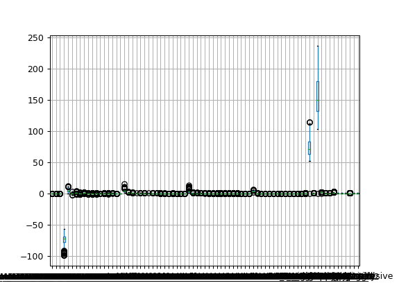

```python
%matplotlib notebook

df.boxplot()
```

#### Podemos perceber que há outliers nas colunas:

- Mean_Acc1298_Mean_Mem40_MFCC_0
- Mean_Acc1298_Std_Mem40_MFCC_0
- Std_Acc1298_Mean_Mem40_MFCC_0

#### Plotando boxplot da coluna Mean_Acc1298_Mean_Mem40_MFCC_0

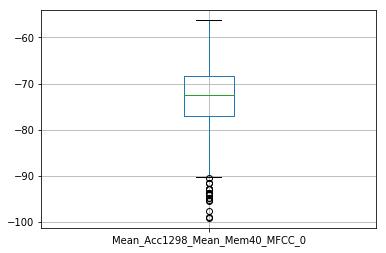

```python
%matplotlib inline
pd.DataFrame(df['Mean_Acc1298_Mean_Mem40_MFCC_0']).boxplot()
```

```python
# Verificando os valores do outlier
df['Mean_Acc1298_Mean_Mem40_MFCC_0'].nsmallest(4)
```

```
85    -99.090802
207   -98.890602
74    -97.510495
468   -95.358974
Name: Mean_Acc1298_Mean_Mem40_MFCC_0, dtype: float64
```

#### Excluindo os outliers

```python
# Excluindo as linhas de indice 85, 207, 74, 468
df.drop([85, 207, 74], axis = 0, inplace = True)
```

#### Analisando outliers na coluna Mean_Acc1298_Std_Mem40_MFCC_0

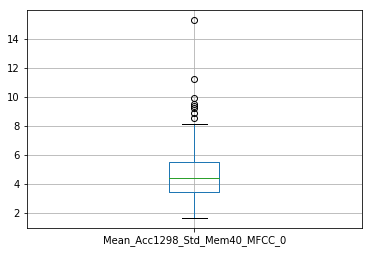

```python
pd.DataFrame(df["Mean_Acc1298_Std_Mem40_MFCC_0"]).boxplot()
```

```python
#Verificando os valores do outlier
df['Mean_Acc1298_Std_Mem40_MFCC_0'].nlargest(3)
```

```
27     15.262381
28     11.216391
525     9.939205
Name: Mean_Acc1298_Std_Mem40_MFCC_0, dtype: float64
```

#### Excluindo os outliers

```python
# Excluindo as linhas de indice 27, 28, 525
df.drop([27,28,525], axis = 0, inplace = True)
```

#### Analisando outliers na coluna Std_Acc1298_Mean_Mem40_MFCC_0

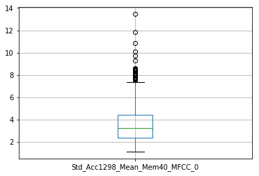

```python
pd.DataFrame(df["Std_Acc1298_Mean_Mem40_MFCC_0"]).boxplot()
```

```python
#Verificando os valores do outlier
df['Std_Acc1298_Std_Mem40_MFCC_0'].nlargest(3)
```

```
360    6.536928
316    5.790787
187    5.620447
Name: Std_Acc1298_Std_Mem40_MFCC_0, dtype: float64
```

```python
# Excluindo as linhas de indice 27, 28, 525
df.drop([360, 316, 187], axis = 0, inplace = True)
```

### Resetando index do dataframe

```python
df = df.reset_index()
```

```python
# Excluindo a coluna index antiga
df.drop('index', axis = 1, inplace = True)
```

### Iremos realizar a normalização de todas as 71 colunas que compõem a entrada do classificador

```python
# Foi utilizada a seguinte função para normalizar os dados
def normalize(df):
    result = df.copy()
    for feature_name in df.columns:
        max_value = df[feature_name].max()
        min_value = df[feature_name].min()
        result[feature_name] = (df[feature_name] - min_value) / (max_value - min_value)
    return result
```

```python
df.iloc[:, :71] = normalize(df.iloc[:, :71])
```

### Separando o dataframe em entrada(x) e saida(y)

```python
x = df.iloc[:, :71]
y = df.iloc[:, 71:]
```

### Verificando balanceamento das classes

```python
labels = ['amazed-suprised', 'happy-pleased' , 'relaxing-calm','quiet-still','sad-lonely','angry-aggresive' ]
quantValues = [y.loc[y['amazed-suprised'] == 1].count()[0], y.loc[y['happy-pleased'] == 1].count()[0] , y.loc[y['relaxing-calm'] == 1].count()[0], y.loc[y['quiet-still'] == 1].count()[0] , y.loc[y['sad-lonely'] == 1].count()[0], y.loc[y['angry-aggresive'] == 1].count()[0]]
```

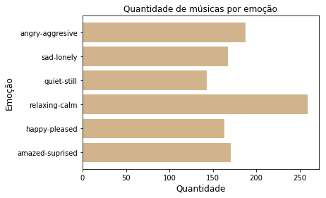

```python
plt.barh(labels, quantValues, color= 'tan')
plt.xlabel('Quantidade', fontsize=12)
plt.ylabel('Emoção', fontsize=12)
plt.title('Quantidade de músicas por emoção')
plt.show()
```

#### No gŕafico de barras acima é possivel observar a quantidade de músicas que há na base para cada classe.

#### Foi realizado uma tentativa de balancear cada classe independentement, mas como a base é multilabel, um balanceamento afetava a outra classe.

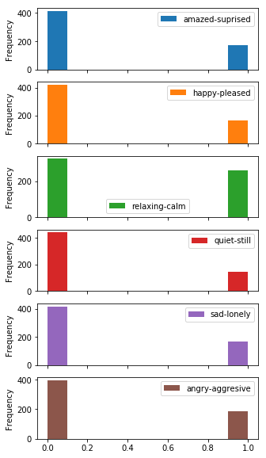

```python
# Histograma das classes
%matplotlib inline
a = y.plot(kind='hist', subplots=True, figsize=(5,10))
```

# Split Data

#### Separando em dados de treino(entrada e saida) e dados de teste(entrada e saida)

#### Foi utilizado 20% para teste e 80% para treinamento

```python
from sklearn.model_selection import train_test_split

x_train, x_test, y_train, y_test = train_test_split( x, y, test_size=0.20, random_state=0)
```

# Métodos de classificação

# KNN CLASSIFIER

#### Usando KNN para realizar a classificação do sentimento da música

#### Para tentar resolver o problema de multilabel iremos utilizar o OneVsRestClassifier. Essa abordagem trata cada rótulo de forma independente, enquanto os classificadores de vários rótulos podem tratar as várias classes simultaneamente, respondendo pelo comportamento correlato entre elas.

#### Foi utilizado K = 9 e Distancia de Manhattan como métrica.

```python
from sklearn.multiclass import OneVsRestClassifier
from sklearn.neighbors import KNeighborsClassifier

knn = OneVsRestClassifier(KNeighborsClassifier(n_neighbors=9, metric = 'manhattan', algorithm = 'brute'))
knn.fit(x_train, y_train)
```

```
OneVsRestClassifier(estimator=KNeighborsClassifier(algorithm='brute',
                                                   leaf_size=30,
                                                   metric='manhattan',
                                                   metric_params=None,
                                                   n_jobs=None, n_neighbors=9,
                                                   p=2, weights='uniform'),
                    n_jobs=None)
```

```python
# Aplica a amostra de teste no modelo
y_pred = knn.predict(x_test)
```

### Acurácia total do método

```python
from sklearn.metrics import accuracy_score
acc = accuracy_score(y_test, y_pred, normalize = True)
acc
```

```
0.3418803418803419
```

#### É notado uma baixa acuracia total do modelo, pois esta acuracia leva em conta o acerto de todas as labels de cada música

#### Verificando os acertos somente entre as classes, ou seja, se o modelo preveu certo cada emoção de musica de forma independente

```python
(y_pred == y_test).mean()
```

```
amazed-suprised    0.811966
happy-pleased      0.683761
relaxing-calm      0.769231
quiet-still        0.940171
sad-lonely         0.863248
angry-aggresive    0.777778
dtype: float64
```

## Análise dos resultados do KNN

### Realizando Matriz de confusão

```python
from sklearn.metrics import confusion_matrix

matrix = confusion_matrix(y_test.values.argmax(axis=1), y_pred.argmax(axis=1))
```

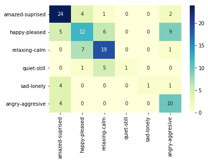

```python
import seaborn as sns
%matplotlib inline
matrix = pd.DataFrame(matrix, index = labels, columns = labels)
sns.heatmap(matrix, annot = True, cmap="YlGnBu")
```

### A matriz de confusão tem como objetivo calcular a quantidade de falso positivo e falso negativo; e de verdadeiro positivo e verdadeiro negativo, também fornece a acurácia e a sensibilidade do modelo.

#### Os valores de verdadeiro positivo se encontram na diagonal principal da matriz

```python
np.array(matrix)
```

```
array([[24,  4,  1,  0,  0,  2],
       [ 5, 12,  6,  0,  0,  9],
       [ 0,  7, 19,  0,  0,  1],
       [ 0,  1,  5,  1,  0,  0],
       [ 4,  0,  0,  0,  1,  1],
       [ 4,  0,  0,  0,  0, 10]])
```

### Sensibilidade

#### Sensibilidade é a proporção de casos positivos que foram identificados corretamente, ou seja, a quantidade de verdadeiro positivo / total. Diz a capacidade do modelo em predizer corretamente a classificação correta.

```python
sensibilidade = []
matriz = np.array(matrix)

for i in range(6):
    TP = 0
    total = 0
    for j in range(6):
        if(i == j):
            TP = matriz[i][j]
        total += matriz[i][j]
    sensibilidade.append(TP/total)
```

### A sensibilidade de cada classe é a seguinte:

```python
pd.DataFrame([sensibilidade], columns = labels).round(3)
```

|  | amazed-suprised | happy-pleased | relaxing-calm | quiet-still | sad-lonely | angry-aggresive |
| --- | --- | --- | --- | --- | --- | --- |
| 0 | 0.774 | 0.375 | 0.704 | 0.143 | 0.167 | 0.714 |

## Especificidade

#### É a proporção de casos negativos que foram identificados corretamente, ou seja, o número de verdadeiros negativos/ total. Diz a capacidade do modelo em predizer corretamente instâncias que não apresentam a classificação.

```python
especificidade = []
totalD = 0

for i in range(6):
    TP = 0
    total = 0
    for j in range(6):
        if(i == j):
            totalD += matriz[i][j]
for i in range(6):
    col = 0
    diag = 0
    for j in range(0,6):
        if(i == j):
            diag = matriz[i][j]
        col += matriz[i][j]
    tn = totalD - diag
    especificidade.append(tn/(tn+(col - diag)))
```

```python
pd.DataFrame([especificidade], columns = labels).round(3)
```

|  | amazed-suprised | happy-pleased | relaxing-calm | quiet-still | sad-lonely | angry-aggresive |
| --- | --- | --- | --- | --- | --- | --- |
| 0 | 0.86 | 0.733 | 0.857 | 0.917 | 0.93 | 0.934 |

### Medida F1

#### Essa medida indica a qualidade geral do modelo, combinando precisão e recall em uma só medida.

```python
from sklearn.metrics import f1_score

pd.DataFrame([f1_score(y_test, y_pred, average = 'micro')], columns = ['F1 Score']).round(3)
```

|  | F1 Score |
| --- | --- |
| 0 | 0.662 |

### Acurácia

#### Como a base é multilabel o calculo pela função do sklearn não leva em conta todas as labels.

#### Ex. Se uma música possui as emoções amazed-suprised e happy-pleased e o modelo classificasse como apenas amazed-suprised a função contaria isso como um erro.

#### No caso da acurácia a partir da matriz de confusão é a proporção de casos que foram corretamente previstos, sejam eles verdadeiro positivo ou verdadeiro negativo de cada classe

```python
tp = 0
tudo = 0

for i in range(6):
    for j in range(6):
        if(i == j):
            tp += matriz[i][j]
        tudo += matriz[i][j]

pd.DataFrame([tp/tudo], columns = ["Acurácia"]).round(3)
```

|  | Acurácia |
| --- | --- |
| 0 | 0.573 |

### Cross Validation com cv = 10

```python
from sklearn.model_selection import cross_val_score

cross_val_score(knn, x_test, y_test, cv=10).mean()
```

```
0.22803030303030303
```

# SVC CLASSIFIER

#### Foi utilizado o SVC Classifier devido a sua facilidade de implementação e inicialmente utilizamos kernel rbf

```python
from sklearn.model_selection import train_test_split

x_train, x_test, y_train, y_test = train_test_split( x, y, test_size=0.20, random_state=0)
```

```python
from sklearn.multiclass import OneVsRestClassifier
from sklearn.svm import SVC

clf = OneVsRestClassifier(SVC(kernel = 'rbf')).fit(x_train, y_train)
clf
```

```
OneVsRestClassifier(estimator=SVC(C=1.0, break_ties=False, cache_size=200,
                                  class_weight=None, coef0=0.0,
                                  decision_function_shape='ovr', degree=3,
                                  gamma='scale', kernel='rbf', max_iter=-1,
                                  probability=False, random_state=None,
                                  shrinking=True, tol=0.001, verbose=False),
                    n_jobs=None)
```

#### Foi necessário utilizar o csc_matrix para deixar as bases no formato de uma matriz linha esparsada para o cálculo da acurácia.

```python
from scipy.sparse import csc_matrix

y_predict = clf.predict(x_test)
parsePred = csc_matrix(y_predict)
parseYtest = csc_matrix(y_test)
```

#### Acurácia do modelo

```python
acc = accuracy_score(parseYtest, parsePred, normalize = True)
acc
```

```
0.3504273504273504
```

#### Acurácia individual de cada classe

```python
(y_predict == y_test).mean()
```

```
amazed-suprised    0.811966
happy-pleased      0.692308
relaxing-calm      0.811966
quiet-still        0.940171
sad-lonely         0.846154
angry-aggresive    0.846154
dtype: float64
```

## Análise dos resultados do SVC

### Matriz de confusão

```python
from sklearn.metrics import confusion_matrix

matrix = confusion_matrix(y_test.values.argmax(axis=1), y_predict.argmax(axis=1))
```

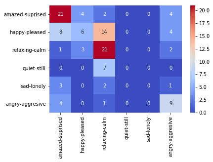

```python
import seaborn as sns
%matplotlib inline
matrix = pd.DataFrame(matrix, index = labels, columns = labels)
sns.heatmap(matrix, annot = True, cmap="coolwarm")
```

```python
matriz = np.array(matrix)
matriz
```

```
array([[21,  4,  2,  0,  0,  4],
       [ 8,  6, 14,  0,  0,  4],
       [ 1,  3, 21,  0,  0,  2],
       [ 0,  0,  7,  0,  0,  0],
       [ 3,  0,  2,  0,  0,  1],
       [ 4,  0,  1,  0,  0,  9]])
```

### Sensibilidade do modelo

```python
sensibilidade = []
matriz = np.array(matrix)

for i in range(6):
    TP = 0
    total = 0
    for j in range(6):
        if(i == j):
            TP = matriz[i][j]
        total += matriz[i][j]
    sensibilidade.append(TP/total)
```

```python
pd.DataFrame([sensibilidade], columns = labels).round(3)
```

|  | amazed-suprised | happy-pleased | relaxing-calm | quiet-still | sad-lonely | angry-aggresive |
| --- | --- | --- | --- | --- | --- | --- |
| 0 | 0.677 | 0.188 | 0.778 | 0.0 | 0.0 | 0.643 |

### Especificidade do modelo

```python
especificidade = []
totalD = 0

for i in range(6):
    TP = 0
    total = 0
    for j in range(6):
        if(i == j):
            totalD += matriz[i][j]
for i in range(6):
    col = 0
    diag = 0
    for j in range(0,6):
        if(i == j):
            diag = matriz[i][j]
        col += matriz[i][j]
    tn = totalD - diag
    especificidade.append(tn/(tn+(col - diag)))
```

```python
pd.DataFrame([especificidade], columns = labels).round(3)
```

|  | amazed-suprised | happy-pleased | relaxing-calm | quiet-still | sad-lonely | angry-aggresive |
| --- | --- | --- | --- | --- | --- | --- |
| 0 | 0.783 | 0.662 | 0.857 | 0.891 | 0.905 | 0.906 |

### F1 Score

```python
from sklearn.metrics import f1_score

pd.DataFrame([f1_score(y_test, y_pred, average = 'micro')], columns = ['F1 Score']).round(3)
```

|  | F1 Score |
| --- | --- |
| 0 | 0.662 |

### Acurácia total do modelo levando em conta o acerto de cada classe

```python
tp = 0
tudo = 0

for i in range(6):
    for j in range(6):
        if(i == j):
            tp += matriz[i][j]
        tudo += matriz[i][j]

pd.DataFrame([tp/tudo], columns = ["Acurácia"]).round(3)
```

|  | Acurácia |
| --- | --- |
| 0 | 0.487 |

# KNN

## Modificando valor de K e utilizando distância de Manhattan.

## K = 9

Sensibilidade

| amazed-suprised | happy-pleased | relaxing-calm | quiet-still | sad-lonely | angry-aggresive |
| --- | --- | --- | --- | --- | --- |
| 0.774 | 0.375 | 0.704 | 0.143 | 0.167 | 0.714 |

Especificidade

| amazed-suprised | happy-pleased | relaxing-calm | quiet-still | sad-lonely | angry-aggresive |
| --- | --- | --- | --- | --- | --- |
| 0.86 | 0.733 | 0.857 | 0.917 | 0.93 | 0.934 |

F1 Score : 0.662

Acurácia: 0.573

## K = 13

Sensibilidade

| amazed-suprised | happy-pleased | relaxing-calm | quiet-still | sad-lonely | angry-aggresive |
| --- | --- | --- | --- | --- | --- |
| 0.806 | 0.219 | 0.667 | 0.143 | 0.0 | 0.714 |

Especificidade

| amazed-suprised | happy-pleased | relaxing-calm | quiet-still | sad-lonely | angry-aggresive |  |
| --- | --- | --- | --- | --- | --- | --- |
| 0.857 | 0.684 | 0.827 | 0.909 | 0.91 | 0.927 |  |

F1 Score : 0.645

Acurácia: 0.521

## K = 19

Sensibilidade

| amazed-suprised | happy-pleased | relaxing-calm | quiet-still | sad-lonely | angry-aggresive |
| --- | --- | --- | --- | --- | --- |
| 0.774 | 0.219 | 0.778 | 0.143 | 0.0 | 0.714 |

Especificidade

| amazed-suprised | happy-pleased | relaxing-calm | quiet-still | sad-lonely | angry-aggresive |
| --- | --- | --- | --- | --- | --- |
| 0.848 | 0.691 | 0.875 | 0.912 | 0.913 | 0.93 |

F1 Score : 0.68

Acurácia: 0.538

## K = 27

Sensibilidade

| amazed-suprised | happy-pleased | relaxing-calm | quiet-still | sad-lonely | angry-aggresive |
| --- | --- | --- | --- | --- | --- |
| 0.742 | 0.281 | 0.778 | 0.0 | 0.0 | 0.714 |

Especificidade

| amazed-suprised | happy-pleased | relaxing-calm | quiet-still | sad-lonely | angry-aggresive |
| --- | --- | --- | --- | --- | --- |
| 0.833 | 0.701 | 0.875 | 0.9 | 0.913 | 0.93 |

F1 Score : 0.682

Acurácia: 0.538

# Métrica de distância

### Variando função distância

## K = 9 Distância: Euclidean

Sensibilidade

| amazed-suprised | happy-pleased | relaxing-calm | quiet-still | sad-lonely | angry-aggresive |
| --- | --- | --- | --- | --- | --- |
| 0.645 | 0.344 | 0.667 | 0.143 | 0.0 | 0.643 |

Especificidade

| amazed-suprised | happy-pleased | relaxing-calm | quiet-still | sad-lonely | angry-aggresive |
| --- | --- | --- | --- | --- | --- |
| 0.78 | 0.696 | 0.82 | 0.906 | 0.908 | 0.909 |

F1 Score : 0.634

Acurácia: 0.504

## K = 9 Distância : Chebyshev

Sensibilidade

| amazed-suprised | happy-pleased | relaxing-calm | quiet-still | sad-lonely | angry-aggresive |
| --- | --- | --- | --- | --- | --- |
| 0.774 | 0.219 | 0.444 | 0.429 | 0.5 | 0.5 |

Especificidade

| amazed-suprised | happy-pleased | relaxing-calm | quiet-still | sad-lonely | angry-aggresive |
| --- | --- | --- | --- | --- | --- |
| 0.821 | 0.662 | 0.746 | 0.93 | 0.946 | 0.875 |

F1 Score : 0.635

Acurácia: 0.479

## K = 9 Distância : Minkowski

Sensibilidade

| amazed-suprised | happy-pleased | relaxing-calm | quiet-still | sad-lonely | angry-aggresive |
| --- | --- | --- | --- | --- | --- |
| 0.645 | 0.344 | 0.667 | 0.143 | 0.0 | 0.643 |

Especificidade

| amazed-suprised | happy-pleased | relaxing-calm | quiet-still | sad-lonely | angry-aggresive |
| --- | --- | --- | --- | --- | --- |
| 0.78 | 0.696 | 0.82 | 0.906 | 0.908 | 0.909 |

F1 Score : 0.634

Acurácia: 0.504

### Entre todos os testes realizados a melhor combinação de K e função de ativação foi: K = 9 e Manhattan.

# Função kernel = rbf

Sensibilidade

| amazed-suprised | happy-pleased | relaxing-calm | quiet-still | sad-lonely | angry-aggresive |
| --- | --- | --- | --- | --- | --- |
| 0.677 | 0.188 | 0.778 | 0.0 | 0.0 | 0.643 |

Especificidade

| amazed-suprised | happy-pleased | relaxing-calm | quiet-still | sad-lonely | angry-aggresive |
| --- | --- | --- | --- | --- | --- |
| 0.783 | 0.662 | 0.857 | 0.891 | 0.905 | 0.906 |

Acurácia: 0.487

# Função kernel = linear

Sensibilidade

| amazed-suprised | happy-pleased | relaxing-calm | quiet-still | sad-lonely | angry-aggresive |
| --- | --- | --- | --- | --- | --- |
| 0.71 | 0.0 | 0.852 | 0.0 | 0.0 | 0.5 |

Especificidade

| amazed-suprised | happy-pleased | relaxing-calm | quiet-still | sad-lonely | angry-aggresive |
| --- | --- | --- | --- | --- | --- |
| 0.769 | 0.619 | 0.879 | 0.881 | 0.897 | 0.865 |

F1 Score : 0.634

Acurácia: 0.444

# Função kernel = poly

Sensibilidade

| amazed-suprised | happy-pleased | relaxing-calm | quiet-still | sad-lonely | angry-aggresive |
| --- | --- | --- | --- | --- | --- |
| 0.71 | 0.281 | 0.519 | 0.286 | 0.0 | 0.357 |

Especificidade

| amazed-suprised | happy-pleased | relaxing-calm | quiet-still | sad-lonely | angry-aggresive |
| --- | --- | --- | --- | --- | --- |
| 0.769 | 0.652 | 0.745 | 0.909 | 0.897 | 0.839 |

F1 Score : 0.634

Acurácia: 0.444